# Part I - (Analysis on Sales and Market Perfomance)

## by (David Kipngeno Kiplangat)

## Introduction

> The sales data is contains records of sales profits and items sold from different regions and segments and by different sales persons from a business environment.

## Preliminary Wrangling

> Load in your dataset and describe its properties through the questions below. Try and motivate your exploration goals through this section.

```
(9976, 29)
<class 'pandas.core.frame.DataFrame'>
RangeIndex: 9976 entries, 0 to 9975
Data columns (total 29 columns):
 #   Column           Non-Null Count  Dtype
---  ------           --------------  -----
 0   CustomerID       9976 non-null   object
 1   CustomerName     9976 non-null   object
 2   BusinessSegment  9976 non-null   object
 3   Country          9976 non-null   object
 4   Region           9976 non-null   object
 5   State            9976 non-null   object
 6   City             9976 non-null   object
 7   PostalCode       9976 non-null   int64
 8   Order ID         9976 non-null   object
```

[output cut: 52 more lines]

- **Data Descriptive Statistics**:
  - computing and understanding the data sammary statistics and its composition for numerical columns only.

|  | PostalCode | ShipID | OrderQty | Discount | Price | Cost | Year | Month | Day | MarkedPrice | BuyingPrice | SellingPrice | Profit |
| --- | --- | --- | --- | --- | --- | --- | --- | --- | --- | --- | --- | --- | --- |
| count | 9976.000000 | 9976.000000 | 9976.000000 | 9976.000000 | 9976.000000 | 9976.000000 | 9976.000000 | 9976.000000 | 9976.000000 | 9976.000000 | 9976.000000 | 9976.000000 | 9976.000000 |
| mean | 55195.237670 | 556349.119186 | 3.705293 | 0.121227 | 60.736603 | 31.252270 | 2019.739074 | 7.737169 | 15.856756 | 223.906328 | 115.347387 | 223.785101 | 108.437714 |
| std | 32055.423413 | 259837.152240 | 2.337438 | 0.154716 | 137.097198 | 70.757570 | 1.128790 | 3.346413 | 8.807517 | 595.794296 | 302.165385 | 595.781480 | 310.645334 |
| min | 1040.000000 | 100030.000000 | 1.000000 | 0.000000 | 0.682900 | 0.414804 | 2018.000000 | 1.000000 | 1.000000 | 0.733300 | 0.414804 | 0.733300 | -0.161554 |
| 25% | 23223.000000 | 331344.000000 | 2.000000 | 0.000000 | 5.666700 | 3.684211 | 2019.000000 | 5.000000 | 8.000000 | 17.268200 | 10.886013 | 17.137175 | 5.668160 |
| 50% | 56560.000000 | 556714.000000 | 3.000000 | 0.000000 | 16.686700 | 9.277181 | 2020.000000 | 9.000000 | 16.000000 | 53.342200 | 30.045813 | 53.281400 | 20.901635 |
| 75% | 90008.000000 | 784421.000000 | 5.000000 | 0.200000 | 61.225800 | 32.303371 | 2021.000000 | 11.000000 | 24.000000 | 201.333400 | 103.566485 | 201.158550 | 93.203829 |
| max | 99301.000000 | 999631.000000 | 18.000000 | 0.500000 | 3773.000000 | 1587.628866 | 2022.000000 | 12.000000 | 31.000000 | 26411.000000 | 10868.724279 | 26410.500000 | 15541.775721 |

### What is/are the main feature(s) of interest in your dataset?

> The main features in the data are the cost, price, region , segment and the net profit attracted from Sales

### What features in the dataset do you think will help support your investigation into your feature(s) of interest?

> I expect that the growth of sales has a corresponding growth of profits so are the cost. I also expect that the profit margins grows progressively with time.

## Univariate Exploration

```
Index(['CustomerID', 'CustomerName', 'BusinessSegment', 'Country', 'Region',
       'State', 'City', 'PostalCode', 'Order ID', 'Order Date', 'ShipID',
       'ItemNum', 'OrderQty', 'Discount', 'Ship Date', 'Ship Mode',
       'Manufacture', 'Category', 'Sub-Category', 'Product Name', 'Price',
       'Cost', 'Year', 'Month', 'Day', 'MarkedPrice', 'BuyingPrice',
       'SellingPrice', 'Profit'],
      dtype='object')
```

I would like to understand the order quantity perfomance

```
count    9976.000000
mean        3.705293
std         2.337438
min         1.000000
25%         2.000000
50%         3.000000
75%         5.000000
max        18.000000
Name: OrderQty, dtype: float64
```

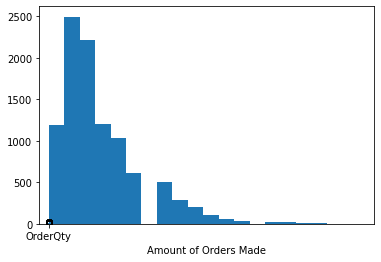

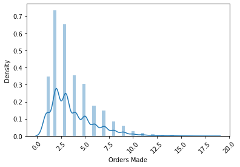

|  | count | mean | std | min | 25% | 50% | 75% | max |
| --- | --- | --- | --- | --- | --- | --- | --- | --- |
| Cost | 9976.0 | 31.25227 | 70.75757 | 0.414804 | 3.684211 | 9.277181 | 32.303371 | 1587.628866 |

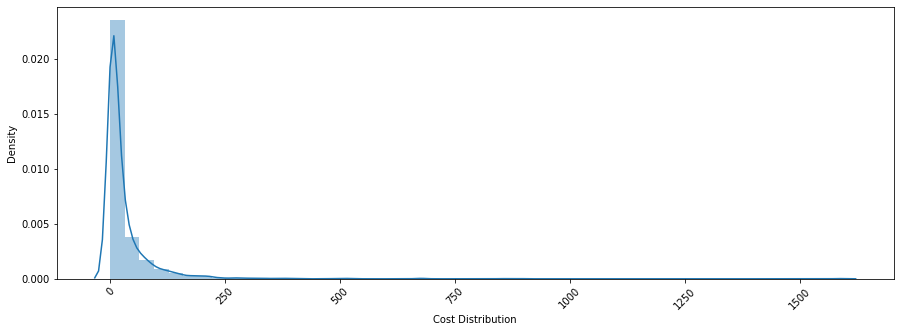

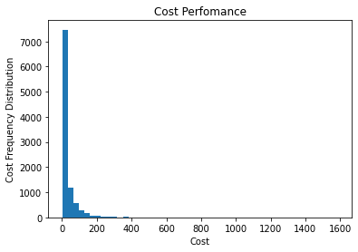

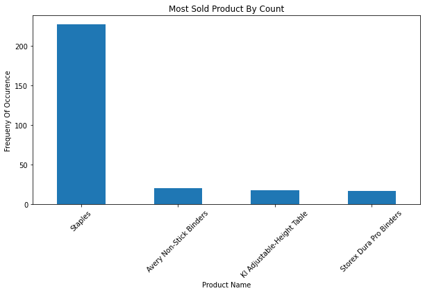

The product staples commanded the most sales ny count as can be observed, the storex dura pro binders come last

- **Understanding the Profit Perfomance**

  ```
    - Profit Distribution outcome
  ```

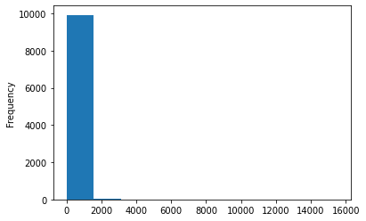

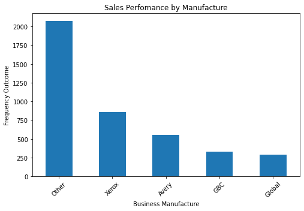

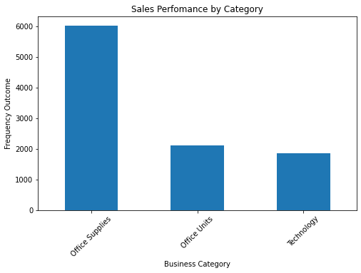

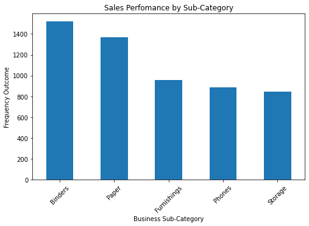

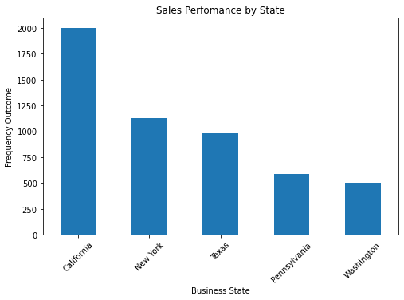

> **manufacturer**: The plot of manufacturer is as shown in the first plot above in the categorical plots. The manufacturer type of other was observed to have the majority count. Following was the manufacturer of xerox then was the very. Global come last. It can be concluded that other manufucturer took the market by far off as compared to other manufacturers.

> **supplies**: As for the sapllies of the items, the suplie of office supplie was the predominant , followed by the office units and lastly was the supplier of the trechnology.

> **Sub Category** : The subcategory would help to understand the distribution of sales by the subcategory. As for this, the subcategory of binders was the leading followed by the category of paper, furnishing and lastly was the subcategory of storage.

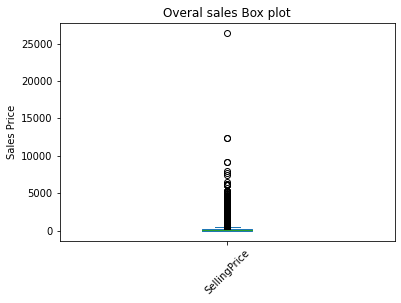

> **Overal Sales** : There was an outlier in the overal sales made, it was an observation made that there was a product sold at a very high price. This was conclusion was reached from the visualization of the box plot above. This was the far i went with univariate data analysis is concerned.

## Bivariate Exploration

> My focus in with bivariate analysis was to find the correlation of variables in the dataset, I compute the correlation and visualize the result. The strongly correlated features would greatly helped to predict the outcome and likely project the future outcome of the business.

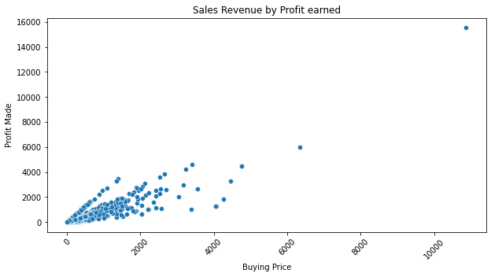

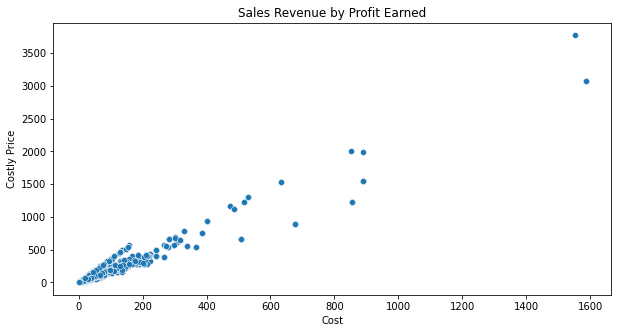

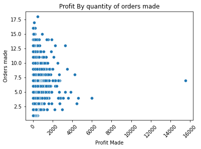

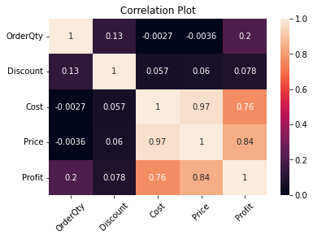

**Segment** Perfomance by Profit

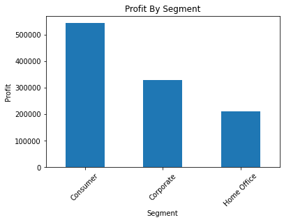

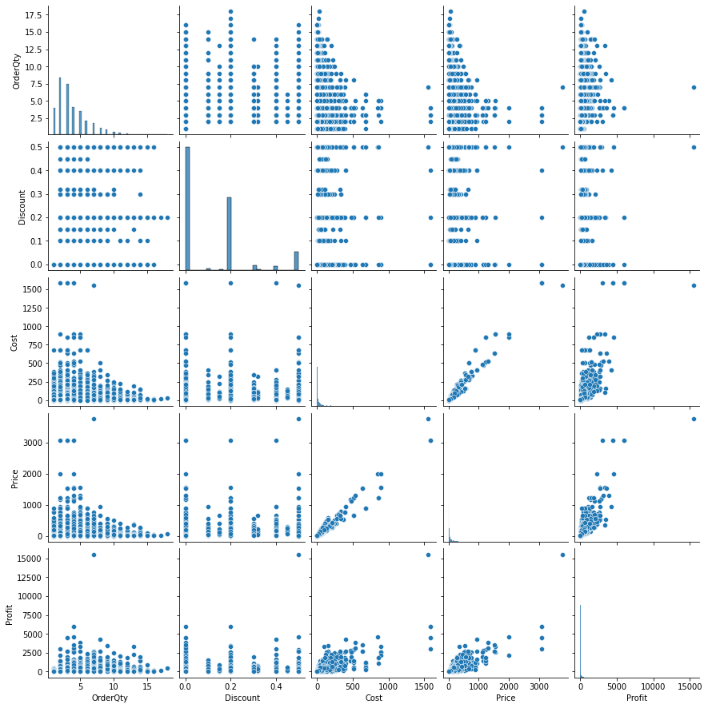

### Talk about some of the relationships you observed in this part of the investigation. How did the feature(s) of interest vary with other features in the dataset?

> It was my observations that the profit was strongly correlated to the cost of commodity, also the price had a linear relationship with a strong positve correlations. I can deduce therefore that the price could be a predictor variable to the cost as it depicted a linear function.

## Multivariate Exploration

> I intend to understand the relationship between multiple variables in this phase. I will investigate the behavior and make visualization with coresponding observations from the data. I have structured this section to answer specific questions mentioned below.

**Question 1 :**What was the yearly sales perfomance?

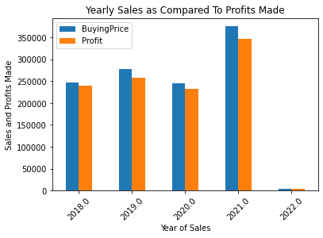

> **Findings** the year of 2021 appeared to have a good perfomance of both profit and sales made from it. The year can therefore be considered the best month for the business.

> **Intrestingly**, there was bearly a harvest in the year of 2022.

**Question 2** what was the Yearly Perfomance by Profits?

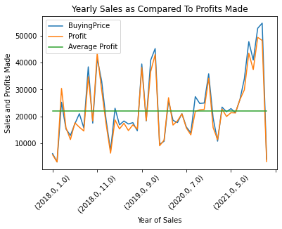

> **Findings** From the figure above shows the perfomance of the sales and profits over time through out the years of sales. The line of average profit perfomance was plotted to show the threshold.

> It was observed that there were years where the profit gain was below the average. This instances can be flagged as danger areas and more market compaigns is required on the products made to make the business live. This consclusions were reached after a careful observations of the figure.

**Question 3** What was the Regional Sales Perfomance

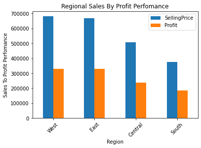

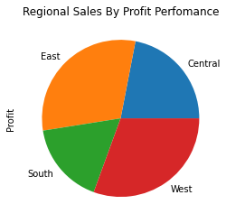

**Question 4:** Who [top 5] brought the most profits and from which business segment and by what amount of Profit

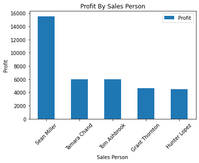

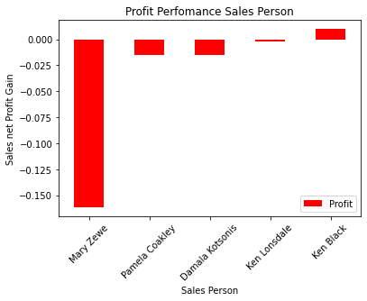

```
                   Profit BusinessSegment   Region         State          City
CustomerName
Mary Zewe       -0.161554       Corporate  Central         Texas     Arlington
Pamela Coakley  -0.015361       Corporate     West      Colorado      Loveland
Damala Kotsonis -0.015361       Corporate     East  Pennsylvania  Philadelphia
Ken Lonsdale    -0.001802        Consumer  Central         Texas       Houston
Ken Black        0.009782       Corporate    South       Florida       Hialeah
```

### Were there any interesting or surprising interactions between features?

> **poor perfoming Sales person** : Mary bought an insignificant profit from her sales , he was followed by pamela coakley. they can be said to have been prbably employing the wrong strategies of sales.

## Conclusions

[output not shown]